# Statistics Case Study: Cross Fell Grazing 2013: Report

CK

8 Sept 2017

### Time run

Time run: 2017-09-14 16:41:07

### Packages

```r
#.libPaths("C:/R/R-3.3.1/library")
library(tidyverse)
library(knitr)
library(ggpubr)
```

### Load data

```r
load(file="CrossFell.data.prepd.rda")
```

# Analyse vegetation heights

## Overview

### Fieldwork

Surveyors measured vegetation height for a variety of taxa on five sucessive surveys on montane grassland at Cross Fell in the North Pennines.

```r
quad.n
```

| year | n.total |
| --- | --- |
| 2003 | 42 |
| 2005 | 44 |
| 2008 | 20 |
| 2010 | 31 |
| 2013 | 56 |

The surveys took place in 2003, 2005, 2008, 2010 and 2013. Survey quadrats were randomly located each year. There were different numbers of quadrats in each survey year.

Species are aggregated into four taxa:

- **Fo** Sheep’s Fescue *Festuca ovina*
- **grm** All gramminoids
- **moss** All mosses and lichen
- **Vm** Bilberry *Vaccinium myrtillus*

### Data processing

The received data was recast into a `tidy` format with each column comprising a variable (taxon, year, height) and each row an individual height measurement. The version of Bilberry data without outliers was used. The result is a table of 3 columns and 1525 rows / measurements:

| taxon | year | height |
| --- | --- | --- |
| moss | 2003 | 2.5 |
| moss | 2003 | 4.5 |
| moss | 2003 | 3.0 |
| moss | 2003 | 2.0 |
| moss | 2003 | 3.0 |
| moss | 2003 | 4.0 |

.

The number of measurements taken of each taxon in each year is as follows:

|  | 2003 | 2005 | 2008 | 2010 | 2013 |
| --- | --- | --- | --- | --- | --- |
| Fo | 131 | 134 | 37 | 35 | 48 |
| grm | 167 | 176 | 80 | 130 | 176 |
| moss | 42 | 43 | 20 | 31 | 47 |
| Vm | 21 | 53 | 44 | 40 | 70 |

The data were saved into the Rdata format file *CrossFell.data.prepd.rda*.

### Results

```r
summary(ht.data)
```

```
  taxon       year         height
 Fo  :385   2003:361   Min.   : 0.500
 grm :729   2005:406   1st Qu.: 2.500
 moss:183   2008:181   Median : 3.500
 Vm  :228   2010:236   Mean   : 4.071
            2013:341   3rd Qu.: 5.000
                       Max.   :17.000
```

The following are the means

```r
####Height means:
ht.means <- ht.data %>%
  group_by(taxon, year) %>%
  summarise(mean = mean(height), median = median(height), sd = sd(height),
            n = length(height))
ht.means %>% print(n=nrow(ht.means))
```

| taxon | year | mean | median | sd | n |
| --- | --- | --- | --- | --- | --- |
| Fo | 2003 | 3.114504 | 3.00 | 1.8703814 | 131 |
| Fo | 2005 | 3.776119 | 3.50 | 1.7130274 | 134 |
| Fo | 2008 | 3.878378 | 4.00 | 0.9159498 | 37 |
| Fo | 2010 | 3.885714 | 4.00 | 1.1948770 | 35 |
| Fo | 2013 | 2.864583 | 2.50 | 1.1286387 | 48 |
| grm | 2003 | 3.278443 | 3.00 | 1.6615829 | 167 |
| grm | 2005 | 4.454545 | 4.00 | 2.2413470 | 176 |
| grm | 2008 | 5.043750 | 4.00 | 2.6315921 | 80 |
| grm | 2010 | 6.450000 | 5.50 | 3.4331094 | 130 |
| grm | 2013 | 5.630682 | 5.00 | 3.2008877 | 176 |

[output cut: 10 more lines]

Plotted this looks as follows:

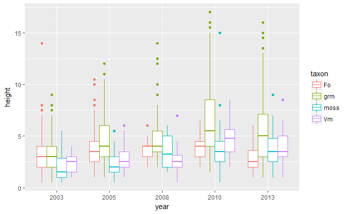

```r
#box plots by height and year for each taxon
ggplot(ht.data, aes(x = year, y= height)) +
  geom_boxplot(aes(colour = taxon))
```

Visually there appears to be some difference in the mean heights taken together. In order to determine if there has in fact been a change in vegetation height over the survey period, and between individual surveys, we need to analyse whether the means have a statistically significant difference.

## Analysis

### Test for Differences in Means

### ANOVA: test assumptions

The most powerful method for testing whether there is a significant change in the height of each taxon between survey years is Analysis of Variance (ANOVA). For us to be able to use this our data must comply with teh following assumptions:

- **Independence of cases**: this is met because each quadrat was selected at random each year.
- **Equality of variances (homoscedasticity)**: we will test for this.
- **Normality**: we will test for this if the variances are equal.

#### Plot data

Key points to look out for

1. Outliers: look for individual points on the box plots. Lots of outliers means the data is unlikely to meet homoscedasticity or normality assumptions.
2. Skewness: High skewness means data is unlikely to be normally distributed. Density plot will be skewed and boxplots will be asymmetrical.
3. Unequal variance: Unequal box sizes will indicate that variances are not equal. If there is little data, then this may not be reliable, as variances can appear unequal when they aren’t.

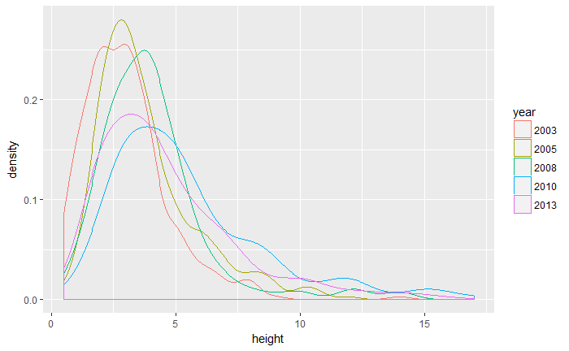

```r
#density plots by height and year
ggplot(ht.data, aes(x= height, colour = year)) +
  geom_density()
```

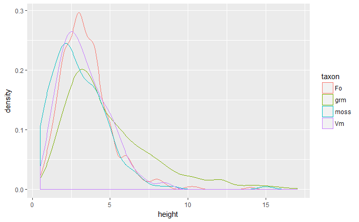

```r
#density plots by height and taxon
ggplot(ht.data, aes(x= height, colour = taxon)) +
  geom_density()
```

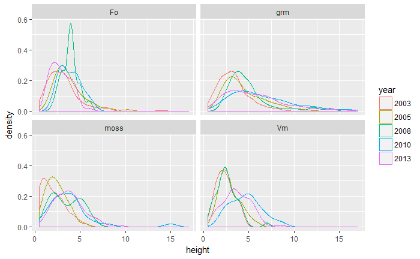

```r
#density plots by height and year for each taxon
ggplot(ht.data, aes(x= height, colour = year)) +
  geom_density() +
  facet_wrap(~taxon)
```

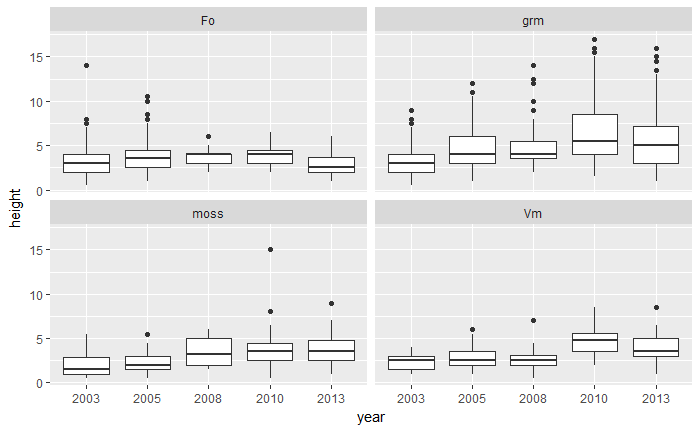

```r
#box plots by height and year for each taxon
ggplot(ht.data, aes(y= height, x = year)) +
  geom_boxplot() +
  facet_wrap(~taxon)
```

##### Comments on the plots:

Lots of outliers in Fest.ov. and graminoids. All four appear to be skewed, in particular there are a lot of 1cm heights. Variances of graminoids appear unequal.

#### Test for homoskedasticity

Testing whether the variances are the same:

Bartlett Test of Homogeneity of Variances: **if the p-value is smaller than 0.05 then data not suitable for ANOVA**

```r
#run test on each taxa in turn (saves resultsht into a list)
bart.l <- as.list(by(ht.data, ht.data$taxon,
             function(x) bartlett.test(height ~ year, data = x)))
#put results from list into a dataframe
bart.df          <- data.frame(cbind(taxon = names(bart.l)))
bart.df$statistic<- bart.l %>% map_dbl("statistic")
bart.df$df       <- bart.l %>% map_dbl("parameter")
bart.df$p.value  <- bart.l %>% map_dbl("p.value")
bart.df$sig.sym  <- as.character(symnum(bart.df$p.value,
                           cutpoints = c(0, 0.001, 0.01, 0.05, 1),
                           symbols = c("***", "**", "*", "")))
bart.df$sig.txt  <- if_else(condition = bart.df$p.value < 0.001,
                            true = "p<0.001",
                            false = paste0("p=", round(bart.df$p.value, digits=3)))
bart.df$method   <- bart.l %>% map_chr("method")
bart.df$formula  <- bart.l %>% map_chr("data.name")
bart.df
```

| taxon | statistic | df | p.value | sig.sym | sig.txt | method | formula |
| --- | --- | --- | --- | --- | --- | --- | --- |
| Fo | 38.00564 | 4 | 1.117563e-07 | *** | p<0.001 | Bartlett test of homogeneity of variances | height by year |
| grm | 97.50340 | 4 | 3.343596e-20 | *** | p<0.001 | Bartlett test of homogeneity of variances | height by year |
| moss | 31.13305 | 4 | 2.875908e-06 | *** | p<0.001 | Bartlett test of homogeneity of variances | height by year |
| Vm | 14.79491 | 4 | 5.146047e-03 | ** | p=0.005 | Bartlett test of homogeneity of variances | height by year |

None of these have homogeneous variances.

The Fligner-Killeen test: **if the p-value is < 0.05 then data not suitable for ANOVA**

```r
#run test on each taxa in turn (saves results into a list)
flig.l <- as.list(by(ht.data, ht.data$taxon,
             function(x) fligner.test(height ~ year, data = x)))
#put results from list into a dataframe
flig.df          <- data.frame(cbind(taxon = names(flig.l)))
flig.df$statistic<- flig.l %>% map_dbl("statistic")
flig.df$df       <- flig.l %>% map_dbl("parameter")
flig.df$p.value  <- flig.l %>% map_dbl("p.value")
flig.df$sig.sym  <- as.character(symnum(flig.df$p.value,
                           cutpoints = c(0, 0.001, 0.01, 0.05, 1),
                           symbols = c("***", "**", "*", "")))
flig.df$sig.txt  <- if_else(condition = flig.df$p.value < 0.001,
                            true = "p<0.001",
                            false = paste0("p=", round(flig.df$p.value, digits=3)))
flig.df$method   <- flig.l %>% map_chr("method")
flig.df$formula  <- flig.l %>% map_chr("data.name")
flig.df
```

| taxon | statistic | df | p.value | sig.sym | sig.txt | method | formula |
| --- | --- | --- | --- | --- | --- | --- | --- |
| Fo | 12.627133 | 4 | 1.324897e-02 | * | p=0.013 | Fligner-Killeen test of homogeneity of variances | height by year |
| grm | 69.577993 | 4 | 2.786637e-14 | *** | p<0.001 | Fligner-Killeen test of homogeneity of variances | height by year |
| moss | 8.783605 | 4 | 6.674188e-02 |  | p=0.067 | Fligner-Killeen test of homogeneity of variances | height by year |
| Vm | 14.653609 | 4 | 5.476304e-03 | ** | p=0.005 | Fligner-Killeen test of homogeneity of variances | height by year |

The variances of the moss data are homogeneous according to this test, but none of the others are.

test for normality using the Anderson Darling test for the composite hypothesis of normality. If p > 0.05 then the distribution is normal.

```r
library(nortest)
ad.test(ht.data$height)
```

```
    Anderson-Darling normality test

data:  ht.data$height
A = 51.484, p-value < 2.2e-16
```

The height data for all species is not normal.

```r
#run test on each taxa and year combination in turn
norm.df.taxa <- ht.data %>%
  group_by(taxon) %>%
  do(broom::tidy(ad.test(.$height)))
norm.df.taxa$sig.sym  <- as.character(symnum(norm.df.taxa$p.value,
                           cutpoints = c(0, 0.001, 0.01, 0.05, 1),
                           symbols = c("***", "**", "*", "")))
norm.df.taxa$sig.txt  <- if_else(condition = norm.df.taxa$p.value < 0.001,
                            true = "p<0.001",
                            false = paste0("p=",
                                           round(norm.df.taxa$p.value, digits=3)))
norm.df.taxa[c(1,2,5,6,3)] %>% arrange(-p.value)
```

| taxon | statistic | sig.sym | sig.txt | p.value |
| --- | --- | --- | --- | --- |
| moss | 3.014464 | *** | p<0.001 | 1.351159e-07 |
| Vm | 3.244178 | *** | p<0.001 | 3.776170e-08 |
| Fo | 7.121749 | *** | p<0.001 | 1.909510e-17 |
| grm | 22.913011 | *** | p<0.001 | 3.700000e-24 |

The distributions of all taxa is not normal.

```r
#run test on each taxa and year combination in turn
norm.df <- ht.data %>%
  group_by(taxon, year) %>%
  do(broom::tidy(ad.test(.$height)))
norm.df$sig.sym  <- as.character(symnum(norm.df$p.value,
                           cutpoints = c(0, 0.001, 0.01, 0.05, 1),
                           symbols = c("***", "**", "*", "")))
norm.df$sig.txt  <- if_else(condition = norm.df$p.value < 0.001,
                            true = "p<0.001",
                            false = paste0("p=",
                                           round(norm.df$p.value, digits=3)))
library(pander)
norm.df[c(1,2,3,6,7,4)] %>% arrange(-p.value)
```

| taxon | year | statistic | sig.sym | sig.txt | p.value |
| --- | --- | --- | --- | --- | --- |
| Vm | 2010 | 0.3875231 |  | p=0.372 | 3.717203e-01 |
| Vm | 2003 | 0.4745657 |  | p=0.216 | 2.159879e-01 |
| moss | 2005 | 0.6063092 |  | p=0.108 | 1.080447e-01 |
| Vm | 2013 | 0.6164418 |  | p=0.105 | 1.045947e-01 |
| Fo | 2010 | 0.6418207 |  | p=0.086 | 8.649408e-02 |
| moss | 2013 | 0.7296560 |  | p=0.053 | 5.327013e-02 |
| Vm | 2008 | 0.7768502 | * | p=0.04 | 4.033839e-02 |
| moss | 2008 | 0.9116392 | * | p=0.016 | 1.626932e-02 |
| Fo | 2013 | 0.9953607 | * | p=0.012 | 1.151496e-02 |
| Vm | 2005 | 1.2506867 | ** | p=0.003 | 2.676464e-03 |

[output cut: 10 more lines]

The distribution of only 6 of the 20 taxon/year combinations are normal.

#### ANOVA: test assumptions - **Conclusion**

As each taxon failed one or more tests for homoscedacity, and the normality assumption is also violated in the majority of cases, we cannot use ANOVA to look for differences in means. We must therefore use an alternative test.

### Non-parametric tests

The Kruskal Wallis test of ranks is non-parametric, which means it does not require the data to be normally distributed or homoscedastic. This means it can handle situations where there are a lot of outliers. It is less powerful than one-way ANOVA, which means more likely fail to detect an effect (type II error), but it is less likely to report an effect if there isn’t one (type I error). The null hypothesis of the test is that data are taken from the same population.

The Kruskal-Wallis test of ranks: **if the p-value is < 0.05 then we reject the null hypothesis that there is no change**

```r
#run test on each taxa in turn (saves results into a list)
krusk.l <- as.list(by(ht.data, ht.data$taxon,
             function(x) kruskal.test(height ~ year, data = x)))
#put results from list into a dataframe
krusk.df          <- data.frame(cbind(taxon = names(krusk.l)))
krusk.df$statistic<- krusk.l %>% map_dbl("statistic")
krusk.df$df       <- krusk.l %>% map_dbl("parameter")
krusk.df$p.value  <- krusk.l %>% map_dbl("p.value")
krusk.df$sig.sym  <- as.character(symnum(krusk.df$p.value,
                           cutpoints = c(0, 0.001, 0.01, 0.05, 1),
                           symbols = c("***", "**", "*", "")))
krusk.df$sig.txt  <- if_else(condition = krusk.df$p.value < 0.001,
                            true = "p<0.001",
                            false = paste0("p=", round(krusk.df$p.value, digits=3)))
krusk.df$method   <- krusk.l %>% map_chr("method")
krusk.df$formula  <- krusk.l %>% map_chr("data.name")
krusk.df
```

[output not shown]

The p-value for all taxa is substantialy below 0.05, which strongly support rejecting the null hypothesis, which suggests that there is significant change in vegetation height

#### Post-hoc testing:

This test does not indicate which pairs of observations are significantly diferent from each other. We can carry out pairwise Mann-Whitney U tests on each pair, given that we have found there to be a significant difference between the groups. In `R` this test uses awkward syntax so we need to filter the data first using `ht.data.test <- filter(ht.data, taxon = "taxon")`

```r
#all taxa - carry out tests and report p values
ht.data.test <- ht.data
pairwise.wilcox.test(x = ht.data.test$height, g = ht.data.test$year, paired = FALSE)
```

```
    Pairwise comparisons using Wilcoxon rank sum test

data:  ht.data.test$height and ht.data.test$year

     2003    2005    2008    2010
2005 3.4e-08 -       -       -
2008 4.4e-09 0.15554 -       -
2010 < 2e-16 4.6e-13 1.0e-06 -
2013 < 2e-16 0.00073 0.15554 0.00073

P value adjustment method: holm
```

Significant differences are found in all successive surveys except 2005-2008.

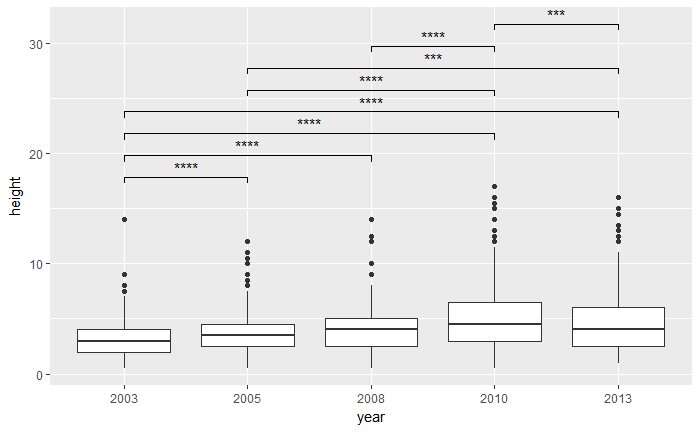

```r
#run test again using function ggpubr::compare_means() to prepare brackets for graphic output.
wilc.pairw <- compare_means(formula = height ~ year,
                            data = ht.data.test,
                            method = "wilcox.test", paired = FALSE)
wilc.pairw <- filter(wilc.pairw, p < 0.05) #select only significant results.
#generate list of brackets
my_comparisons <- list()
for (i in 1:nrow(wilc.pairw)) {
  my_comparisons[[i]] <- c(wilc.pairw$group1[i], wilc.pairw$group2[i])
  }
#prepare plot
p <- ggplot(ht.data.test, aes(x = year, y = height)) +
  geom_boxplot()
# Add pairwise comparisons p-value to plot
p + stat_compare_means(comparisons = my_comparisons,
                       label = "p.signif",
                       hide.ns = FALSE)
```

```r
#Sheep's fescue
ht.data.test <- filter(ht.data, taxon == "Fo")
pairwise.wilcox.test(x = ht.data.test$height, g = ht.data.test$year, paired = FALSE)
```

```
cannot compute exact p-value with tiescannot compute exact p-value with tiescannot compute exact p-value with ties
```

```
    Pairwise comparisons using Wilcoxon rank sum test

data:  ht.data.test$height and ht.data.test$year

     2003    2005    2008    2010
2005 0.00157 -       -       -
2008 0.00051 0.42054 -       -
2010 0.00344 0.79890 1.00000 -
2013 1.00000 0.00464 0.00057 0.00202

P value adjustment method: holm
```

For Sheep’s fescue, there is a significant change from 2003-2005 (p = 0.00157) and 2010-2013 (p = 0.00202). There is no significant change between the last survey in 2013 and the first survey in 2003.

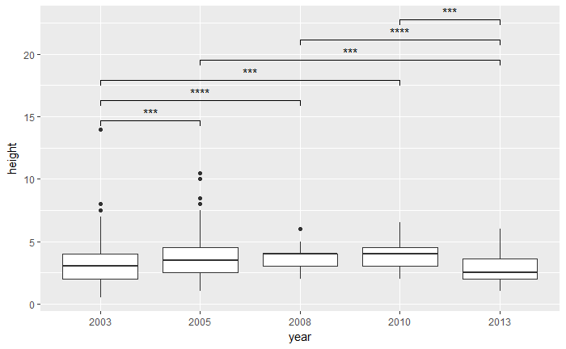

```r
#run test again using function ggpubr::compare_means() to prepare brackets for graphic output.
wilc.pairw <- compare_means(formula = height ~ year,
                            data = ht.data.test,
                            method = "wilcox.test", paired = FALSE)
wilc.pairw <- filter(wilc.pairw, p < 0.05) #select only significant results.
#generate list of brackets
my_comparisons <- list()
for (i in 1:nrow(wilc.pairw)) {
  my_comparisons[[i]] <- c(wilc.pairw$group1[i], wilc.pairw$group2[i])
  }
#prepare plot
p <- ggplot(ht.data.test, aes(x = year, y = height)) +
  geom_boxplot()
# Add pairwise comparisons p-value to plot
p + stat_compare_means(comparisons = my_comparisons,
                       label = "p.signif",
                       hide.ns = FALSE)
```

```r
#all graminoids
ht.data.test <- filter(ht.data, taxon == "grm")
pairwise.wilcox.test(x = ht.data.test$height, g = ht.data.test$year, paired = FALSE)
```

```
    Pairwise comparisons using Wilcoxon rank sum test

data:  ht.data.test$height and ht.data.test$year

     2003    2005    2008   2010
2005 4.3e-06 -       -      -
2008 1.3e-08 0.0845  -      -
2010 < 2e-16 2.9e-07 0.0065 -
2013 7.6e-13 0.0049  0.2283 0.0845

P value adjustment method: holm
```

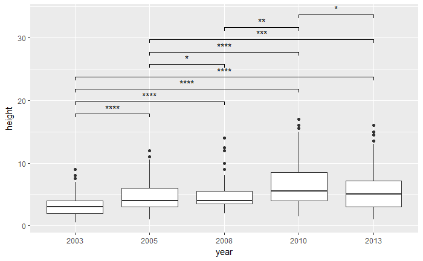

```r
#run test again using function ggpubr::compare_means() to prepare brackets for graphic output.
wilc.pairw <- compare_means(formula = height ~ year,
                            data = ht.data.test,
                            method = "wilcox.test", paired = FALSE)
wilc.pairw <- filter(wilc.pairw, p < 0.05) #select only significant results.
#generate list of brackets
my_comparisons <- list()
for (i in 1:nrow(wilc.pairw)) {
  my_comparisons[[i]] <- c(wilc.pairw$group1[i], wilc.pairw$group2[i])
  }
#prepare plot
p <- ggplot(ht.data.test, aes(x = year, y = height)) +
  geom_boxplot()
# Add pairwise comparisons p-value to plot
p + stat_compare_means(comparisons = my_comparisons,
                       label = "p.signif",
                       hide.ns = FALSE)
```

For all graminoids there is signifcant difference between 2003-2005 (p < 0.0001) and 2008-2010 (p = 0.0065). The difference between teh original survey in 2003 and the final survey in 2013 is significant (p<0.0001)

```r
#Mosses and lichen
ht.data.test <- filter(ht.data, taxon == "moss")
pairwise.wilcox.test(x = ht.data.test$height, g = ht.data.test$year, paired = FALSE)
```

[output not shown]

```
    Pairwise comparisons using Wilcoxon rank sum test

data:  ht.data.test$height and ht.data.test$year

     2003    2005    2008    2010
2005 0.24835 -       -       -
2008 0.00385 0.06739 -       -
2010 0.00039 0.00804 1.00000 -
2013 3.2e-06 0.00017 1.00000 1.00000

P value adjustment method: holm
```

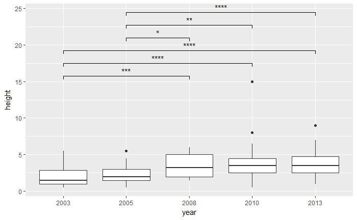

```r
#run test again using function ggpubr::compare_means() to prepare brackets for graphic output.
wilc.pairw <- compare_means(formula = height ~ year,
                            data = ht.data.test,
                            method = "wilcox.test", paired = FALSE)
wilc.pairw <- filter(wilc.pairw, p < 0.05) #select only significant results.
#generate list of brackets
my_comparisons <- list()
for (i in 1:nrow(wilc.pairw)) {
  my_comparisons[[i]] <- c(wilc.pairw$group1[i], wilc.pairw$group2[i])
  }
#prepare plot
p <- ggplot(ht.data.test, aes(x = year, y = height)) +
  geom_boxplot()
# Add pairwise comparisons p-value to plot
p + stat_compare_means(comparisons = my_comparisons,
                       label = "p.signif",
                       hide.ns = FALSE)
```

For mosses and lichen there was no significant difference between successive surveys. However, the 2003 heights were significantly different the final survey in 2013 (p<0.0001)

```r
#bilberry
ht.data.test <- filter(ht.data, taxon == "Vm")
pairwise.wilcox.test(x = ht.data.test$height, g = ht.data.test$year, paired = FALSE)
```

```
cannot compute exact p-value with tiescannot compute exact p-value with tiescannot compute exact p-value with ties
```

```
    Pairwise comparisons using Wilcoxon rank sum test

data:  ht.data.test$height and ht.data.test$year

     2003    2005    2008    2010
2005 0.38333 -       -       -
2008 0.66002 0.43356 -       -
2010 1.5e-05 5.6e-06 6.8e-07 -
2013 0.00269 0.00956 0.00052 0.02334

P value adjustment method: holm
```

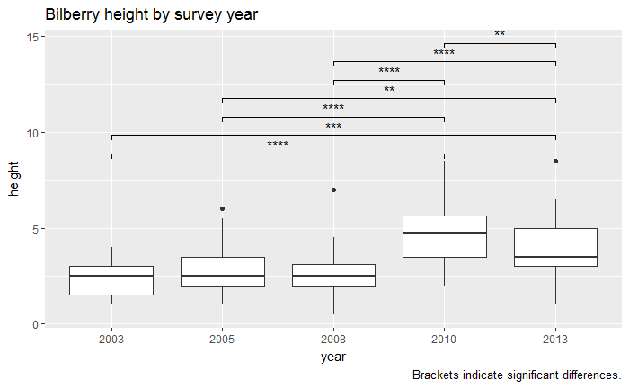

```r
#run test again using function ggpubr::compare_means() to prepare brackets for graphic output.
wilc.pairw <- compare_means(formula = height ~ year,
                            data = ht.data.test,
                            method = "wilcox.test", paired = FALSE)
wilc.pairw <- filter(wilc.pairw, p < 0.05) #select only significant results.
#generate list of brackets
my_comparisons <- list()
for (i in 1:nrow(wilc.pairw)) {
  my_comparisons[[i]] <- c(wilc.pairw$group1[i], wilc.pairw$group2[i])
  }
#prepare plot
p <- ggplot(ht.data.test, aes(x = year, y = height)) +
  geom_boxplot()
# Add pairwise comparisons p-value to plot
p + stat_compare_means(comparisons = my_comparisons,
                       label = "p.signif",
                       hide.ns = FALSE) +
  labs(title = "Bilberry height by survey year", caption = "Brackets indicate significant differences.")
```

For bilberry, the 2008 heights differed significantly from the 2010 survey (p<0.0001). The heights in 2003 were significantly different from the mean height in 2013 (p = 0.00269)

```r
rm(ht.data.test) #clean up
```

[figure not shown]

```r
#box plots by height and year for each taxon
ggplot(ht.means, aes(x = year, y= mean, group = taxon, colour = taxon)) +
  geom_point() +
  geom_line()  +
  ylim(0,9) +
  labs(caption = "Figure 3. Mean height of key vegetation components: bilberry, sheep’s fescue, and moss and lichens",
       x = "Mean height (cm)", y = "Survey year")
```

```r
 # facet_wrap(~taxon)
```